# Moduli Spaces

## 16.1 The Cotangent Complex

For $X \xrightarrow{f} Y$, we have $L_{X/Y} \in D {\mathrm{QCoh}}(X)$, the derived category of quasicoherent sheaves on $X$. This answers the extension question:

For any square-zero thickening $Y \hookrightarrow Y'$ (a closed immersion) with ideal $I$ yields an ${\mathcal{O}}_{Y}{\hbox{-}}$module.

Some special cases: $X \to Y$ smooth yields $L_{X/Y} = \Omega_{X/Y}[0]$ concentrated in degree zero.

$Y = \operatorname{Spec}k$ and $Y' = \operatorname{Spec}k[\varepsilon]$ yields
$$\begin{align*}
\mathrm{obs} \in \operatorname{Ext}_{x}^2(\Omega_{X/Y}, {\mathcal{O}}_{x})= H^2(T_{X_{/k}})
.\end{align*}$$

For $X\hookrightarrow Y$ is a regular embedding (closed immersion and locally a regular sequence) $L_{X/Y} = \qty{I/I^2}[1]$, the conormal bundle.

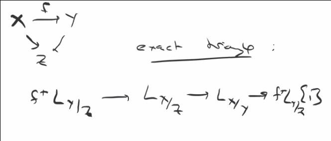

Diagram

For $Y$ smooth, $X \hookrightarrow Y$ a regular embedding, $L_{X_{/k}} = \Omega_{X_{/k}}$ with $\mathrm{obs}/\mathrm{def} = \operatorname{Ext}^{2/1}(\Omega_{x}, {\mathcal{O}})$ and the infinitesimal automorphisms are the homs.

For $Y = \operatorname{Spec}k[x, y] = {\mathbb{A}}^2$ and $X = \operatorname{Spec}B = V(f) \subset {\mathbb{A}}^2$ we get
$$\begin{align*}
0 \to I/I^2 \to \Omega_{X_{/k}} \otimes B &\to \Omega_?{X_{/k}} \to 0 \\ \\
& \Downarrow \quad \text{equals} \\ \\
0 \to B \xrightarrow{1 \mapsto (f_{x}, f_{y})} &B^2 \to \Omega_{B_{/k}} = L_{X_{/k}} \to 0
.\end{align*}$$

Taking $\hom({\,\cdot\,}, B)$ yields

[figure not shown]

So ,
$$\begin{align*}
\mathrm{obs} &= 0 \\
\mathrm{def} &= B/(f_{x}, f_{y})B \\
\operatorname{Aut}&\neq 0
.\end{align*}
and$$

We have the following obstruction theories:

- For abstract deformations, we have
  $$\begin{align*}
  X_{0} {}_{/k} \text{ smooth } \implies
  \operatorname{Aut}/\mathrm{def}/\mathrm{obs} = H^{0/1/2}(T_{X_{0}})
  .\end{align*}$$
- For embedded deformations, $Y_{0}/k$ smooth, $X_{0} \hookrightarrow Y_{0}$ regular, we have
  $$\begin{align*}
  \operatorname{Aut}/\mathrm{def}/\mathrm{obs} = 0, H^{0/1}(N_{X_{0}/Y_{0}})
  .\end{align*}$$

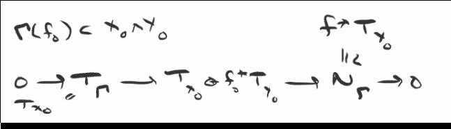

Diagram

Since all of these structures are special cases of the cotangent complex, they place nicely together in the following sense: Given $X \hookrightarrow_{i} Y$ we have
$$\begin{align*}
0 \to T_{X} \to i^* T_{Y} \to N_{X/Y} \to 0
.\end{align*}$$

Yielding a LES
$$\begin{align*}
0 &\to H^0(T_{X}) \to H^0(i^* T_{Y}) \to H^0(N_{X/Y}) \\
&\to H^1(T_{X}) \to H^1(i^* T_{Y}) \to H^1(N_{X/Y}) \\
&\to H^2(T_{X})
.\end{align*}$$

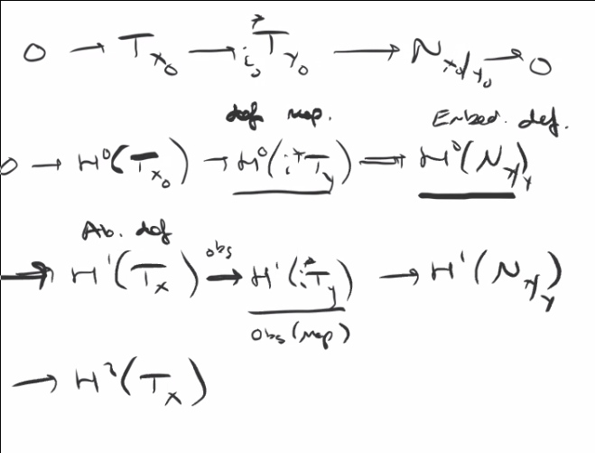

Diagram

Consider $X \subset {\mathbb{P}}^3$ a smooth quartic, and show that $\mathrm{def}(X) \cong k^{20}$ but $\mathrm{def}_{\text{embedded}} \cong k^{19}$. This is a quartic K3 surface for which deformations don’t lift (non-algebraic, don’t sit inside any ${\mathbb{P}}^n$).

> Next time: Obstruction theory of sheaves, T1 lifting as a way to show unobstructedness.

# 17 Characterization of Smoothness (Thursday April 16th)

> Recap from last time: the cotangent complex answers an extension problem.

Given $X \xrightarrow{f} Y$ and $Y \hookrightarrow Y'$ a square zero thickening. When can the pullback diagram be filled in?

[figure not shown]

- The existence is governed by $\mathrm{obs} \in \operatorname{Ext}^2( L_{X/Y}, f^* I)$
- The number of extensions by $\operatorname{Ext}^1( L_{X/Y}, f^* I)$
- The automorphisms by $\operatorname{Ext}^0( L_{X/Y}, f^* I)$

Suppose we’re considering $k[\varepsilon] \to k$, where $L_{X_{/k}} = \Omega_{X_{/k}}$, and $H^*(T_{X_{/k}})$ houses the obstruction theory. For an embedded deformation $X \hookrightarrow Y$, we have

[figure not shown]

## 17.1 T1 Lifting

This will give a criterion for a pro-representable functor to be smooth. We’ve seen a condition on $F$ with obstruction theory for the hull to be smooth, namely $\mathrm{obs}(F) = 0$. However, often $F = h_{R}$ will have $R$ smooth with a natural obstruction theory for which $\mathrm{obs}(F) \neq 0$.

For $X_{/k}$ smooth projective, the picard functor ${\operatorname{Pic}}_{X_{/k}}$ is smooth because we know it’s an abelian variety. We also know that the natural obstruction space is $\mathrm{obs} = H^2({\mathcal{O}}_{X})$, which may be nonzero. We could also have abstract deformations given by $H^2(T_{X})$

Given $A \in \operatorname{Art}_{/k}$ and $M$ a finite length $A{\hbox{-}}$module, we can form the ring $A \oplus M$ where $M$ is square zero and $A\curvearrowright M$ by the module structure. This yields
$$\begin{align*}
0 \to M \to A \oplus M \to A \to 0
\end{align*}$$

The explicit ring structure is given by $(x, y) \cdot (x, y') = (xx', x'y + xy')$.

Assume $\operatorname{ch}k =0$ and $F$ is a pro-representable deformation functor, so $F = \hom(R, \cdot)$ where $R$ is a complete local $k{\hbox{-}}$algebra with $\dim t_{R} < \infty$.

Then $R$ is smooth[^9] over $k$ $\iff$ for all $A\in \operatorname{Art}_{/k}$ and all $M, M' \in A{\hbox{-}}\text{mod}$ finite dimensional with $M \twoheadrightarrow M'$, we have

$$\begin{align*}
F(A\oplus M) \twoheadrightarrow F(A\oplus M')
.\end{align*}$$

### 17.1.1 Proof of Proposition

First observe that $\ker(F(A\oplus M) \to F(A)) = \ker(\hom(R, A\oplus M) \to \hom(R, A))$, note that if we have two morphisms

[figure not shown]

denoting these maps $h, h'$ we have

1. $g-g' \in \operatorname{Der}_{k}(R, M)$, since
   $$\begin{align*}
   (h-h')(x, y)
   &= h(x)h(y) - h'(x) h'(y) \\
   &= (f(x)f(y), f(x)g(y) + f(y)g(x) ) - (f(x)f(y), f(x) g'(y) + f(y) g'(x)) \\
   &= f(x)(g-g')(y) + f(y)(g-g')(x)
   .\end{align*}$$
2. Given $g: R\to A\oplus M$ and $\theta \in \operatorname{Der}_{k}(R, M)$, then $g + \theta: R \to A\oplus M$.

We conclude that the fibers are naturally torsors for $\operatorname{Der}_{k}(R, M)$ if nonempty. It is in fact a canonically trivial torsor, since there is a distinguished element in each fiber. Thus to show the following, it is enough to show surjection on fibers and trivial extensions go to trivial ones, then $\operatorname{Der}_{k}(R, M) \to \operatorname{Der}_{k}(R, M')$ with $0\mapsto 0$.

[figure not shown]

The criterion for $F$ being surjective is equivalent to
$$\begin{align*}
\operatorname{Der}_{k}(R, M) &\twoheadrightarrow\operatorname{Der}_{k}(R, M') \\ \\
&\Downarrow \qquad \text{identified as }\\ \\
\hom_{R}(\Omega_{R_{/k}}, M) &\twoheadrightarrow\hom(\Omega_{R_{/k}'}, M')
.\end{align*}$$

$\Omega_{R_{/k}}$ is complicated. An example is
$$\begin{align*}
\Omega_{k[[x]]/k} \otimes k((x)) = \Omega_{k((x))/k}
.\end{align*}
which is an infinite dimensional \(k((x))\) vector space.$$

Here we only need to consider the completions $\hom_{R}(\widehat{\Omega}_{R_{/k}}, M) \twoheadrightarrow\hom(\widehat{\Omega}_{R_{/k}'}, M') = k[[x]]~dx$.

In characteristic zero, $R?k$ is smooth iff $\widehat{\Omega}_{R_{/k}}$ is free.

Thus the surjectivity condition is equivalent to checking that $\hom(\widehat{\Omega}_{R_{/k}}, {\,\cdot\,})$ is right-exact on finite length modules. This happens iff $\widehat{\Omega}$ are projective iff they are free.

Uses an algebra fact: for a complete finitely-generated module $M$ over a complete ring, then $M$ is free if $M$ projective with respect to sequences of finite-length modules. Over a local ring, finitely-generated and projective implies free.

This is powerful – allows showing deformations of Calabi-Yaus are unobstructed!

A smooth projective $X_{/k}$ is **Calabi-Yau** iff
$$\begin{align*}
\omega_{x} \cong {\mathcal{O}}_{x}
,\end{align*}
i.e. the canonical bundle is trivial.$$

$X_{/k}$ CY with $H^0(T_{X}) = 0$ (implying that the deformation functor $F$ of $X$ is pro-representable, say by $R$, and has no infinitesimal automorphisms) has unobstructed deformations, i.e. $R$ is smooth of dimension $H^1(T_{X})$.

Note that $H^2(T_{X}) \neq 0$ in general, so this is a finer criterion.

Take $X \subset {\mathbb{P}}^4$ a smooth quintic threefold.

- By adjunction, this is Calabi-Yau since
  $$\begin{align*}
  \omega_{x} = \omega_{{\mathbb{P}}^4}(5) \mathrel{\Big|}_{X} = {\mathcal{O}}_{x}
  .\end{align*}$$
- By Lefschetz,
  $$\begin{align*}
  H^i_\mathrm{sing} ({\mathbb{P}}^4, {\mathbb{C}})
  &\xrightarrow{\cong}
  H^i_{\mathrm{sing}}(X, {\mathbb{C}})
  && \text{except in middle dimension} \\ \\
  &\Downarrow \quad \text{ implies} \\ \\
  H^{3, 1}
  &= H^{1, 3} = 0
  .\end{align*}$$
- By Serre duality,
  $$\begin{align*}
  H^0(T_{x}) &= 0 \cong H^4(\Omega_{x} \otimes\omega_{x}) \\ \\
  &\Downarrow \quad\text{implies} \\ \\
  H^3(\Omega_{x}) &= H^{3, 1} = 0
  .\end{align*}$$

There are nontrivial embedded deformations that yield the same abstract deformations, write them down for the quintic threefold.

The abstract moduli space here is given by $\operatorname{PGL}(5) \setminus\operatorname{Hilb}$ where $\operatorname{Hilb}$ is smooth.

### 17.1.2 Proof that obstructions to deformations of Calabi-Yaus are unobstructed

We need to show that for any $M \twoheadrightarrow M'$ that
$$\begin{align*}
F(A\oplus M) \twoheadrightarrow F(A\oplus M')
.\end{align*}
The fibers of the LHS are extensions from \(A\) to \(A\oplus M\), and the RHS are extensions of \(X/A\)? By dualizing, we need to show \(H^1(T_{X/A}\otimes M ) \twoheadrightarrow H^1(T_{X/A} \otimes M')\) since the LHS is \(\operatorname{Ext}^1(\Omega_{X/A}, M)\). We want the bottom map here to be surjective:$$

[figure not shown]

For $X/A$ a deformation of a CY, $H^*(T_{X/A})$ is free. This will finish the proof, since the map is given by $H^1(T_{X/A}) \otimes M \twoheadrightarrow H^1(T_{X/A}) \otimes M'$ by exactness. This uses the fact that there’s a spectral sequence
$$\begin{align*}
\operatorname{Tor}_{q}(H^p(T_{X/A}), M) \implies H^{p+q} (T_{X/A} \otimes M)
\end{align*}
which follows from base change and uses the fact that \(T_{X/A}\) is flat.$$

We’ll be looking at $\operatorname{Tor}_{1}(H^0(T_{X/A}), M)$ which is zero by freeness. Hodge theory is now used: by Deligne-Illusie, for $X\xrightarrow{f} S$ smooth projective, taking pushforwards $R^p f_* \Omega^q_{X_{/S}}$ are free (coming from degeneration of Hodge to de Rham) and commutes with base change.

This implies that $\omega_{X/A} = {\mathcal{O}}_{X}$ is trivial. Using Deligne-Illusie, since $\omega$ is trivial on the special fiber, $H^0(\omega_{X/A}) = A$ is free of rank 1. We thus have a section ${\mathcal{O}}_{X} \to \omega_{X/A}$ which is an isomorphism by flatness, since it’s an isomorphism on the special fiber.

By Serre duality, $H^1(T_{X/A}) = H^{n-1}(\Omega_{X/A} \otimes\omega_{X/A}) ^\vee= H^{n-1}(\Omega_{X/A})^\vee$, which is free by Deligne-Illusie. This also holds for $H^0(T_{X/A}) = H^n(\Omega_{X/A})^\vee$ is free.

Thus deformations of Calabi-Yaus are unobstructed.

### 17.1.3 Remarks

In fact we need much less. Take $A_{n} = k[t] / t^n$, then consider

[figure not shown]

For a deformation $X/A_{n}$, let $T^1(X/A_{n}) = \ker(F(A_{n}[\varepsilon]) \to F(A_{n}) )$, the fiber above $X/A_{n}$. Then Kuramata shows that one only needs to show surjectivity for these kinds of extensions, which is quite a bit less.

In the T1 lifting theorem, the condition is equivalent to the following: For any deformation $X/A_{n+1}$, there is a map
$$\begin{align*}
T^1(X/A_{n+1}) \to T^1(X\otimes A_{n} / A_{n})
.\end{align*}
and surjectivity is equivalent to the lifting condition. In the CY situation, the extension group \(T^1(X/A_{n+1}) = H^1(T_{X/A_{n+1}})\) and the RHS is \(H^1(T_{X\otimes A_{n} / A_{n}})\). So the slogan for the T1 lifting property is the following:$$

If the deformation space is free and commutes with base change, then deformations are unobstructed.

Commuting with base change means the RHS is $H^1(T_{X/A_{n}}) \otimes A_{n}$, so we just need to show it’s free?

# 18 Monday April 27th

## 18.1 Principle of Galois Cohomology

Let $\ell_{/k}$ a galois extension and $X_{/k}$ some “object” for which it makes sense to associate another object over $\ell$. We’ll prove that there’s a correspondence
$$\begin{align*}
\left\{{\substack{
\ell_{/k}, \text{ twisted forms} \\
Y \text{ of } X_{/k}
}}\right\}
&\rightleftharpoons
H^1(\ell_{/k}, \operatorname{Aut}(X_{/\ell}))
.\end{align*}$$

Recall that $\operatorname{PGL}(n ,\ell) \mathrel{\vcenter{:}}=\operatorname{GL}(n ,\ell) / \ell^{\times}$.

Let $X = {\mathbb{P}}^{n-1}/k$, then $H^1(\ell_{/k}, \operatorname{PGL}(n, \ell)$ parameterizes twisted forms of ${\mathbb{P}}^{n-1}$, e.g. for $n=2$ twisted forms of ${\mathbb{P}}^1$ and plane curves.

Take $X = M_{n}(k)$ the algebra of $n\times n$ matrices. Then by a theorem (Skolern-Noether) $\operatorname{Aut}(M_{n}(k)) = \operatorname{PGL}(n, k)$. Thus $H^1(\ell_{/k}, \operatorname{PGL}(n, k))$ also parameterizes twisted forms of $M_{n}(k)$ in the category of unital (not necessarily commutative) $k{\hbox{-}}$algebras. These are exactly central simple algebras $A_{/k}$ where $\dim_{k} A = n^2$ with center $Z(A) = k$ with no nontrivial two-sided ideals. By taking $\ell = k^{s}$, we get a correspondence
$$\begin{align*}
\left\{{\substack{\text{CSAs} A_{/k} \text{ of degree } n}}\right\}
&\rightleftharpoons
\left\{{\substack{\text{ Severi-Brauer varieties of dimension n-1} }}\right\}
.\end{align*}
Taking \(n=2\) we obtain
\begin{align*}
\left\{{\substack{\text{Quaternion algebras } A_{/k}}}\right\}
&\rightleftharpoons
\left\{{\substack{\text{Genus 0 curves } \ell_{/k}}}\right\}
.\end{align*}$$

## 18.2 The Weil Descent Criterion

Fix $\ell_{/k}$ finite Galois with $g \mathrel{\vcenter{:}}=\operatorname{Aut}(\ell_{/k})$.

1. $X_{/k} \to X_{/\ell}$ with a $g{\hbox{-}}$action.
2. What additional data on an $\ell{\hbox{-}}$variety $Y_{/\ell}$ do we need in order to “descend the base” from $\ell$ to $k$?

For $\sigma \in g$, write $\ell^\sigma$ to denote $\ell$ given the structure of an $\ell{\hbox{-}}$algebra via $\sigma: \ell \to \ell^\sigma$. If $X_{/\ell}$ is a variety, so is $X^\sigma_{/\ell}$?

[figure not shown]

where $f$ is the map induced on $\operatorname{Spec}$ by $\sigma$. We can also think of these on defining equations:
$$\begin{align*}
X &= \operatorname{Spec}\ell[t_{1}, \cdots, t_{n}] / \left\langle{p_{1}, \cdots, p^n}\right\rangle \\
X^\sigma &= \operatorname{Spec}\ell[t_{1}, \cdots, t_{n}] / \left\langle{\sigma_{p_{1}}, \cdots, \sigma{p^n}}\right\rangle \\
.\end{align*}$$

For $X_{/k}, X_{/\ell}$, we canonically identify $X$ with $X^\sigma$ by the map $f_\sigma: X \xrightarrow{\cong} X^\sigma$, a canonical isomorphism of $\ell{\hbox{-}}$varieties. We thus have

[figure not shown]

under a “cocycle condition” $f_{\sigma \tau} = {}^\sigma f_\tau \circ f_\sigma$.

Given $Y_{/\ell}$ quasi-projective and $\forall \sigma \in g$ we have descent datum $f_\sigma: Y\xrightarrow{\cong} Y^\sigma$ satisfying the above cocycle condition, and there exists a unique $X_{/k}$ such that $X_{/\ell} \xrightarrow{\cong} Y_{/\ell}$ and the descent data coincide.

### 18.2.1 An Application

Let $X_{/k}$ be a quasiprojective variety and $Y_{/k}$ and $\ell_{/k}$ twisted forms. Then $a_{0} \in Z' (\ell_{/k}, \operatorname{Aut}X)$. Conversely, we have the following:

Let $a_{0}$ be such a cocycle and $\left\{{s_\sigma: X\to X^\sigma}\right\}$ be descent datum attached to $X$. Define twisted descent datum $g_\sigma \mathrel{\vcenter{:}}= f_\sigma \circ a_\sigma$ from
$$\begin{align*}
X /\ell\xrightarrow{a_\sigma} X_{/\ell} \xrightarrow{f_\sigma} X^\sigma / \ell
.\end{align*}$$

Check that $g_\sigma$ satisfies the cocycle condition, so by Weil uniquely determines a ($k{\hbox{-}}$model) $Y_{/k}$ of $X_{/\ell}$.

Let $G_{/k}$ be a smooth algebraic group and $X_{/k}$ a torsor under $G$. Then ${\operatorname{Aut}}(G) \supset \operatorname{Aut}_{G{\hbox{-}}\text{torsor}} (G) = G$, since in general the translations will only be a subgroup of the full group of automorphisms. Then
$$\begin{align*}
H^1(\ell_{/k}, G) \to H^1(\ell_{/k}, \operatorname{Aut}G)
\end{align*}
defines a twisted form \(X\) of \(G\). How do you descend the torsor structure? This is possible, but not covered in Bjoern’s book! This requires expressing the descent data more functorially – see the book on Neron models.$$

## 18.3 The Cohomology Theory

### 18.3.1 Motivation

Let $G_{/k}$ be a smooth connected commutative algebraic group where $\operatorname{ch}k$ does not divide $n$, so the map $[n]: G \to G$ is an isogeny. Then
$$\begin{align*}
0 \to G[n] (k^{s} ) \to G(k^{s} ) \xrightarrow{[n]} G(k^{s} ) \to 0
\end{align*}
is a SES of \(g = \operatorname{Aut}(k^{s}_{/k}){\hbox{-}}\)modules.$$

Taking the associated cohomology sequence yields the Kummer sequence:
$$\begin{align*}
0 \to G(k) / nG(k) \to H^1(k, G[n]) \to H^1(k, G)[n] \to 0
\end{align*}
where the RHS is the Weil–Châtelet group and the LHS is the Mordell-Weil group.$$

> The end!

# 19 Bibliography

1.

Bakker, B.: https://sites.google.com/view/benbakker/math-8330-s20/lectures-8330

2.

Hartshorne, R.: Algebraic geometry. Springer (2010)

3.

Strømme, S.A.: http://matwbn.icm.edu.pl/ksiazki/bcp/bcp36/bcp36111.pdf

4.

Hartshorne, R.: Deformation theory. Springer (2010)

5.

Fantechi, B., Lothar, G., Illusie, L., Kleiman, S.L., Nitsure, N., Vistoli, A.: Fundamental algebraic geometry: Grothendiecks FGA explained. American Mathematical Society (2005)

6.

Mumford, D.: Lectures on curves on an algebraic surface. Princeton University Press (1985)

7.

Harris, J., Morrison, I.: Moduli of curves. Springer (1998)

[^1]: $F\leq G$ is a subfunctor iff $F(s) \hookrightarrow G(s)$.
[^2]: See tilde construction in Hartshorne, essentially amounts to localizing free tings.
[^3]: Think of this as a graded module, this tells you the lowest number of small grade pieces needed to determine the entire thing.
[^4]: Note: $h^1 = \dim H^1$.
[^5]: Not a unique map, but still a pullback
[^6]: Recall that right-exactness was a transitive action.
[^7]: Recall that by Nakayama, a nonzero module tensor $k$ can not be zero.
[^8]: For flat maps, tensoring up to an isomorphism implies isomorphism.
[^9]: I.e. $R \cong k[[t_{R}^\vee]]$.